# Concrete Strength Prediction Model by Warren Camp

Objective

To predict the concrete strength using the data available in file concrete_data.xls. Apply feature engineering and model tuning to obtain 80% to 95% of R2 score.

Resources Available

The data for this project is available in file https://archive.ics.uci.edu/ml/machine-learning-databases/concrete/compressive/.

Attribute Information:

Given are the variable name, variable type, the measurement unit and a brief description. The concrete compressive strength is the regression problem. The order of this listing corresponds to the order of numerals along the rows of the database.

Name --Data Type --Measurement --Description

- Cement(cement) --quantitative --kg in a m3 mixture --Input Variable
- Blast Furnace Slag (slag) --quantitative --kg ina m3 mixture --Input Variable
- Fly Ash (ash) --quantitative --kg ina m3 mixture --Input Variable
- Water (water) --quantitative --kg in a m3 mixture --Input Variable
- Superplasticizer (superplastic) --quantitative --kg in a m3 mixture --Input Variable
- Coarse Aggregate (coarseagg) --quantitative --kg in a m3 mixture --Input Variable
- Fine Aggregate (fineagg) --quantitative --kg in a m3 mixture --Input Variable
- Age(age) --quantitative --Day (1~365) --Input Variable
- Concrete compressive strength(strength) --quantitative --MPa --Output Variable

```python
# Import Python Libraries

import warnings
warnings.filterwarnings('ignore')
```

```python
#  machine learning library
import numpy as np
import matplotlib.pyplot as plt
import matplotlib.dates as mdates
import seaborn as sns
import pandas as pd
import statsmodels.api as sm


# Import Linear Regression Models
from sklearn.model_selection import KFold, cross_val_score, cross_val_predict, GridSearchCV, train_test_split
from sklearn.linear_model import LinearRegression, Ridge, Lasso
from sklearn.tree import DecisionTreeRegressor
from sklearn.ensemble import GradientBoostingRegressor
from sklearn.svm import SVR
from sklearn.metrics import r2_score, mean_squared_error, confusion_matrix
from sklearn.preprocessing import MinMaxScaler, Normalizer # Creates values {0, 1}

from matplotlib.dates import DateFormatter

from statsmodels.base.model import LikelihoodModelResults
from statsmodels.regression.linear_model import OLS

from collections import defaultdict

from pandas.api.types import CategoricalDtype

from datetime import datetime as dt

# Show plots
%matplotlib inline
```

```python
# Read input file and create dataframe
df = pd.DataFrame(pd.read_csv('concrete.csv'))
```

# Exploratory data quality report reflecting the following

## 1. Univariate analysis –data types and description of the independent attributes which should include (name, meaning, range of values observed, central values (mean and median), standard deviation and quartiles, analysis of the body of distributions / tails, missing values, outliers

```python
# Univariate analysis - Explore the contents of concrete.csv file
print(df.shape)
print(df.columns)
```

```
(1030, 9)
Index(['cement', 'slag', 'ash', 'water', 'superplastic', 'coarseagg',
       'fineagg', 'age', 'strength'],
      dtype='object')
```

```python
print(df.head(5))
print(df.tail(5))
```

```
   cement   slag    ash  water  superplastic  coarseagg  fineagg  age  \
0   141.3  212.0    0.0  203.5           0.0      971.8    748.5   28
1   168.9   42.2  124.3  158.3          10.8     1080.8    796.2   14
2   250.0    0.0   95.7  187.4           5.5      956.9    861.2   28
3   266.0  114.0    0.0  228.0           0.0      932.0    670.0   28
4   154.8  183.4    0.0  193.3           9.1     1047.4    696.7   28

   strength
0     29.89
1     23.51
2     29.22
3     45.85
4     18.29
      cement   slag    ash  water  superplastic  coarseagg  fineagg  age  \
1025   135.0    0.0  166.0  180.0          10.0      961.0    805.0   28
1026   531.3    0.0    0.0  141.8          28.2      852.1    893.7    3
1027   276.4  116.0   90.3  179.6           8.9      870.1    768.3   28
1028   342.0   38.0    0.0  228.0           0.0      932.0    670.0  270
1029   540.0    0.0    0.0  173.0           0.0     1125.0    613.0    7

      strength
1025     13.29
1026     41.30
1027     44.28
1028     55.06
1029     52.61
```

### Analysis: There are 1030 concrete observations and 9 columns of data. There are 8 features of independent data. The target is concrete compressive strength (column: strength) ).

```python
print(df.describe())
```

```
            cement         slag          ash        water  superplastic  \
count  1030.000000  1030.000000  1030.000000  1030.000000   1030.000000
mean    281.167864    73.895825    54.188350   181.567282      6.204660
std     104.506364    86.279342    63.997004    21.354219      5.973841
min     102.000000     0.000000     0.000000   121.800000      0.000000
25%     192.375000     0.000000     0.000000   164.900000      0.000000
50%     272.900000    22.000000     0.000000   185.000000      6.400000
75%     350.000000   142.950000   118.300000   192.000000     10.200000
max     540.000000   359.400000   200.100000   247.000000     32.200000

         coarseagg      fineagg          age     strength
count  1030.000000  1030.000000  1030.000000  1030.000000
mean    972.918932   773.580485    45.662136    35.817961
std      77.753954    80.175980    63.169912    16.705742
min     801.000000   594.000000     1.000000     2.330000
25%     932.000000   730.950000     7.000000    23.710000
50%     968.000000   779.500000    28.000000    34.445000
75%    1029.400000   824.000000    56.000000    46.135000
max    1145.000000   992.600000   365.000000    82.600000
```

```python
print(df.info())
```

```
<class 'pandas.core.frame.DataFrame'>
RangeIndex: 1030 entries, 0 to 1029
Data columns (total 9 columns):
 #   Column        Non-Null Count  Dtype
---  ------        --------------  -----
 0   cement        1030 non-null   float64
 1   slag          1030 non-null   float64
 2   ash           1030 non-null   float64
 3   water         1030 non-null   float64
 4   superplastic  1030 non-null   float64
 5   coarseagg     1030 non-null   float64
 6   fineagg       1030 non-null   float64
 7   age           1030 non-null   int64
 8   strength      1030 non-null   float64
dtypes: float64(8), int64(1)
memory usage: 72.5 KB
None
```

```python
# Check for null values (missing values)
print(df.isnull().sum())
print(df.isnull().apply(pd.value_counts))
```

```
cement          0
slag            0
ash             0
water           0
superplastic    0
coarseagg       0
fineagg         0
age             0
strength        0
dtype: int64
       cement  slag   ash  water  superplastic  coarseagg  fineagg   age  \
False    1030  1030  1030   1030          1030       1030     1030  1030

       strength
False      1030
```

### Analysis: There are no null or missing values.

```python
# Check for the number zero values values,  True indicates Zeros value
for i in df.columns:
    print(pd.DataFrame(df[i]==0.0).apply(pd.value_counts))
```

```
       cement
False    1030
       slag
False   559
True    471
       ash
True   566
False  464
       water
False   1030
       superplastic
False           651
True            379
       coarseagg
False       1030
       fineagg
False     1030
        age
False  1030
       strength
False      1030
```

### Analysis: cement, water, course agg, fine agg, age, and strength have no zero values. slag, ash, superplastic have large number of zero values. Assumed that zero is a valid value indicating that specific mixture did not contain any of those ingredients.

```python
# Count the number of zeros per column
df.isin([0]).sum()
```

```
cement            0
slag            471
ash             566
water             0
superplastic    379
coarseagg         0
fineagg           0
age               0
strength          0
dtype: int64
```

### Analysis: Initially concerned about the affect of zero values, then I realized that a zero indicated that this mterial was not a component of the concrete mixture. No action was taken.

```python
for i in df.columns:
    print(i, df[i].nunique())
```

```
cement 278
slag 185
ash 156
water 195
superplastic 111
coarseagg 284
fineagg 302
age 14
strength 845
```

```
      count
0         2
1         0
2         1
3         2
4         1
...     ...
1025      1
1026      2
1027      0
1028      2
1029      3

[1030 rows x 1 columns]
```

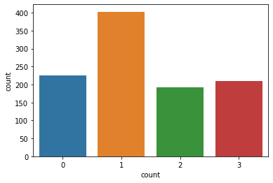

```python
# Count and plot the number zeros by row
temp = pd.DataFrame((df == 0).astype(int).sum(axis=1))
temp.rename(columns={0:'count'}, inplace=True)
print(temp)
sns.countplot(x='count', data=temp)
```

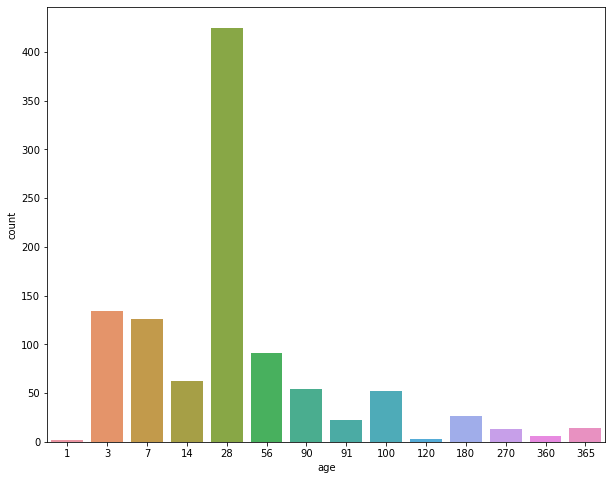

```python
# Check for number for unique strength values by age
plt.figure(figsize=(10,8))
sns.countplot(x='age', data=df)
```

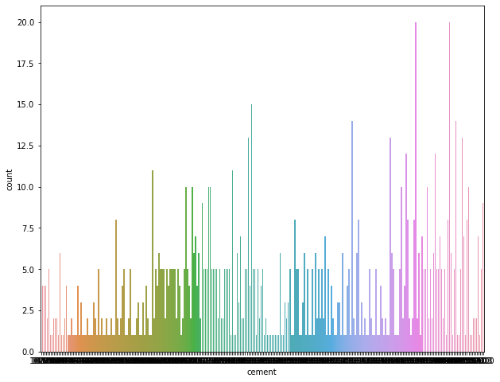

```python
# Check for number for unique strength values by age
plt.figure(figsize=(10,8))
sns.countplot(x='cement', data=df)
```

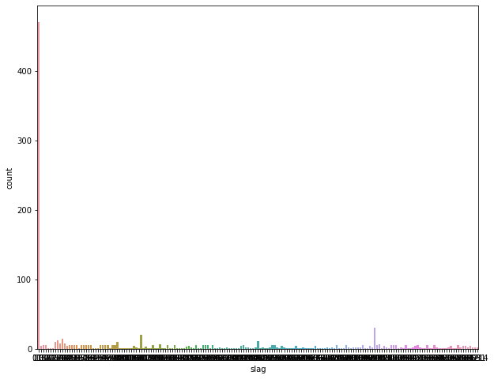

```python
# Check for number for unique strength values by age
plt.figure(figsize=(10,8))
sns.countplot(x='slag', data=df)
```

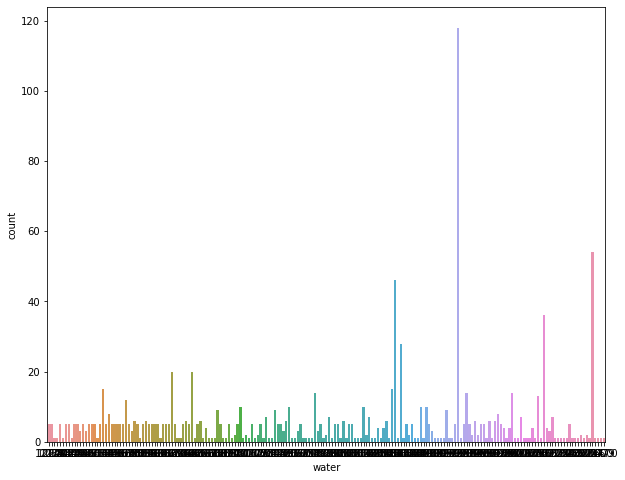

```python
# Check for number for unique strength values by age
plt.figure(figsize=(10,8))
sns.countplot(x='water', data=df)
```

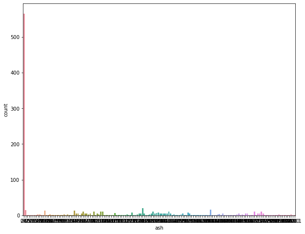

```python
# Check for number for unique strength values by age
plt.figure(figsize=(10,8))
sns.countplot(x='ash', data=df)
```

```python
print(df)
```

```
      cement   slag    ash  water  superplastic  coarseagg  fineagg  age  \
0      141.3  212.0    0.0  203.5           0.0      971.8    748.5   28
1      168.9   42.2  124.3  158.3          10.8     1080.8    796.2   14
2      250.0    0.0   95.7  187.4           5.5      956.9    861.2   28
3      266.0  114.0    0.0  228.0           0.0      932.0    670.0   28
4      154.8  183.4    0.0  193.3           9.1     1047.4    696.7   28
...      ...    ...    ...    ...           ...        ...      ...  ...
1025   135.0    0.0  166.0  180.0          10.0      961.0    805.0   28
1026   531.3    0.0    0.0  141.8          28.2      852.1    893.7    3
1027   276.4  116.0   90.3  179.6           8.9      870.1    768.3   28
1028   342.0   38.0    0.0  228.0           0.0      932.0    670.0  270
1029   540.0    0.0    0.0  173.0           0.0     1125.0    613.0    7

      strength
0        29.89
1        23.51
2        29.22
3        45.85
4        18.29
...        ...
1025     13.29
1026     41.30
1027     44.28
1028     55.06
1029     52.61

[1030 rows x 9 columns]
```

## 2. Bi-variate analysis between the predictor variables and between the predictor variables and target column. Comment on your findings in terms of their relationship and degree of relation if any. Visualize the analysis using boxplots and pair plots, histograms or density curves.

```python
print('Max: \n', df.groupby('age').max())
print('Mean: \n', df.groupby('age').mean())
print('Median: \n', df.groupby('age').median())
```

```
Max:
      cement   slag    ash  water  superplastic  coarseagg  fineagg  strength
age
1     500.0    0.0    0.0  200.0           0.0     1125.0    763.0     12.64
3     540.0  305.3  174.7  214.6          32.2     1134.3    992.6     41.64
7     540.0  359.4  141.0  228.0          32.2     1134.3    992.6     59.09
14    540.0  129.9  174.7  214.6          14.2     1125.0    905.9     59.76
28    540.0  359.4  200.1  247.0          32.2     1145.0    992.6     81.75
56    531.3  282.8  174.7  214.6          32.2     1134.3    992.6     80.20
90    540.0  305.3    0.0  228.0           0.0     1125.0    945.0     69.66
91    531.3  262.2    0.0  186.0          32.2     1134.3    992.6     82.60
100   376.0  129.9  174.7  214.6          14.2     1090.0    905.9     66.95
120   349.0    0.0    0.0  192.0           0.0     1056.0    830.0     40.86
180   540.0  237.5    0.0  228.0           0.0     1125.0    885.0     71.62
270   540.0  237.5    0.0  228.0           0.0     1125.0    670.0     74.17
```

[output cut: 70 more lines]

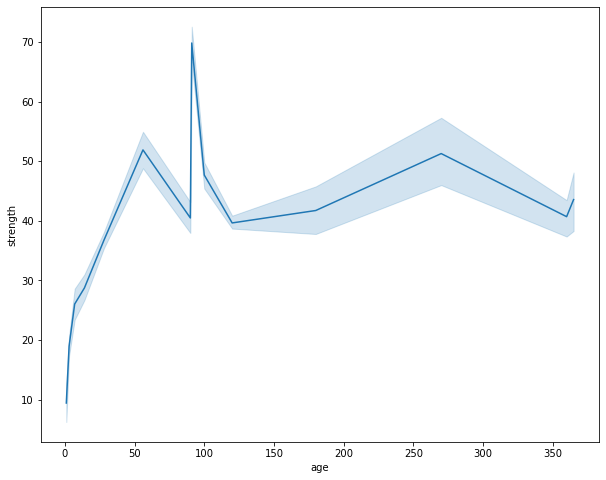

```python
plt.figure(figsize=(10,8))
sns.lineplot(x='age', y='strength', data=df, markers=True)
```

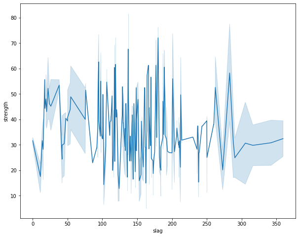

```python
plt.figure(figsize=(10,8))
sns.lineplot(x='slag', y='strength', data=df, markers=True)
```

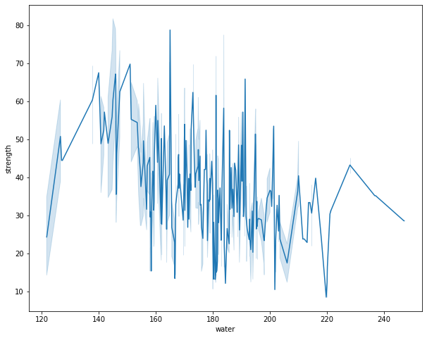

```python
plt.figure(figsize=(10,8))
sns.lineplot(x='water', y='strength', data=df, markers=True)
```

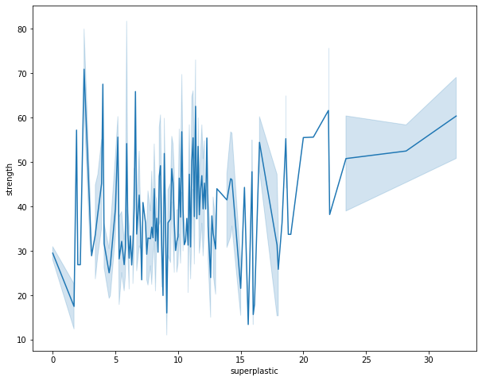

```python
plt.figure(figsize=(10,8))
sns.lineplot(x='superplastic', y='strength', data=df, markers=True)
```

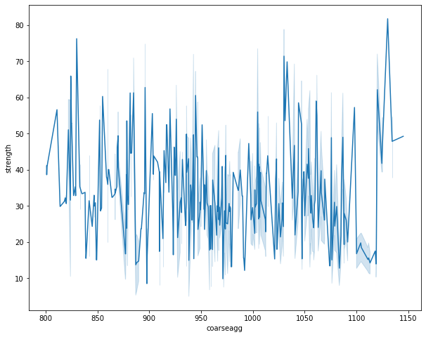

```python
plt.figure(figsize=(10,8))
sns.lineplot(x='coarseagg', y='strength', data=df, markers=True)
```

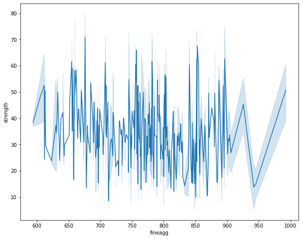

```python
plt.figure(figsize=(10,8))
sns.lineplot(x='fineagg', y='strength', data=df, markers=True)
```

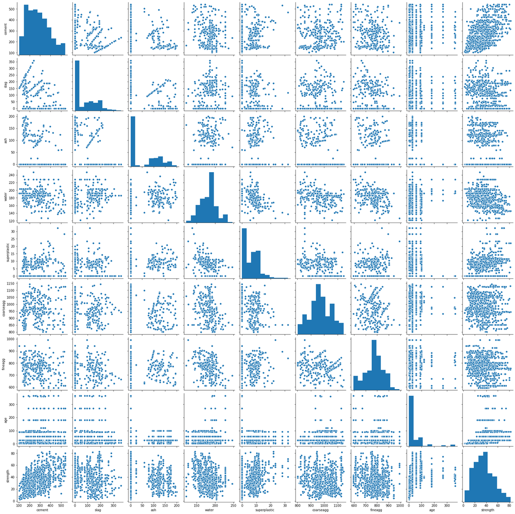

```python
plt.figure(figsize=(10,8))
sns.pairplot(df);
plt.show()
```

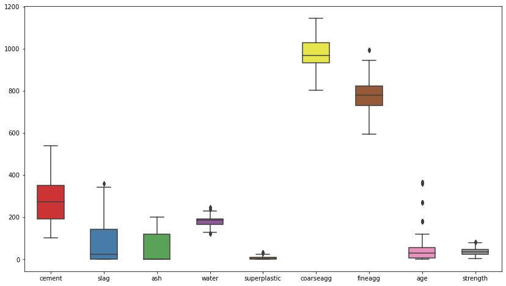

```python
plt.figure(figsize=(14,8))
sns.boxplot(data=df, orient="v", palette="Set1", whis=1.5, width=0.5)
```

```python
outlier_columns = ['slag', 'water', 'superplastic', 'fineagg', 'age', 'strength']
for f in outlier_columns:
    q3 = df[f].quantile(q = 0.75)
    q2 = df[f].quantile(q = 0.25)
    IRQ = q3 - q2
    upper_bound = q3 + IRQ * 1.5
    arr = df[f].to_numpy()
    print('\n', f, ' outliers include: \n')
    for i in range(len(arr)):
        if (arr[i] > upper_bound):
            print(f, i, arr[i])
```

```
 slag  outliers include:

slag 918 359.4
slag 990 359.4

 water  outliers include:

water 66 247.0
water 263 246.9
water 740 237.0
water 826 236.7

 superplastic  outliers include:

superplastic 44 28.2
superplastic 156 28.2
superplastic 232 32.2
superplastic 292 32.2
superplastic 538 28.2
superplastic 744 32.2
superplastic 816 32.2
superplastic 838 28.2
superplastic 955 32.2
superplastic 1026 28.2

 fineagg  outliers include:

fineagg 129 992.6
fineagg 447 992.6
fineagg 504 992.6
fineagg 584 992.6
fineagg 857 992.6

 age  outliers include:

age 51 180
age 64 365
age 93 180
age 99 180
age 103 180
```

[output cut: 46 more lines]

```
age 919 360
age 951 270
age 957 365
age 971 180
age 985 180
age 995 365
age 1017 180
age 1028 270

 strength  outliers include:

strength 192 81.75
strength 732 79.99
strength 950 82.6
strength 1003 80.2
```

### Analysis: Based on the boxplots: slag (2 outliers), water (4 outliers), superplastic (10 outliers), fineagg (5 outliers), age (50+outliers ), and strength (4 outliers) contain outliers, where the upper bound is q3 + IRQ * 1.5, see calaculations below. My major concern was with the number of outliers for age. No adjustments were made to the the outliers becasue there values appear to be resonable, at this time. No extreme adnormal values that could affect the model fit were identified.

## 3. Feature Engineering techniques

- Identify opportunities (if any) to extracta new feature from existing features, drop a feature(if required)
- Get data model ready and do a train test split.
- Decide on complexity of the model, should it be simple linear model in terms of parameters or would aquadratic or higher degree.

### Analysis: There appears two independents classes: age and the mixture. Mixtrue is the amount of cement, slag, water, superplastic. The combination of age and mixture will predict the dependent variavle, strength. The pairplots and the correlation matrix below do not readly idetify any features that can be dropped.

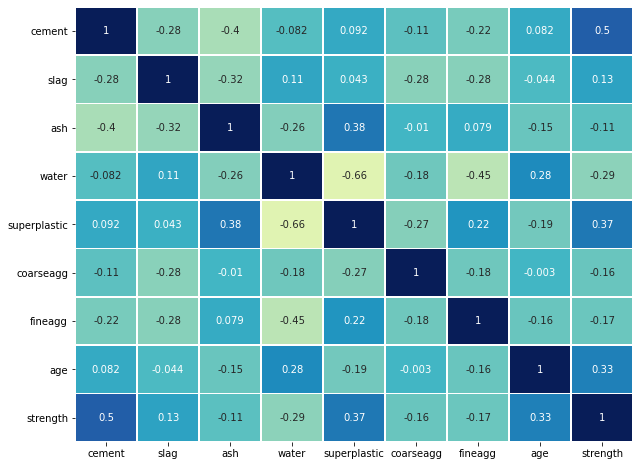

```python
plt.figure(figsize=(10,8))

sns.heatmap(df.corr(),
            annot=True,
            linewidths=.5,
            center=0,
            cbar=False,
            cmap="YlGnBu")
plt.show()
```

### Analysis: The conventional process of testing the compressive strength of concrete involves ... strength of concrete with maximum accuracy and lowest error (evaluation metrics MAE ) ... 1 day 16%; 3 days 40%; 7 days 65%; 14 days 90%; 28 days 99%.

### Compressive Strength Table of Concrete at 7 & 28 Days

Grade of Concrete Minimum compressive strength N/mm2 at 7 days Specified characteristic compressive strength (N/mm2) at 28 days M15 10 15 M20 13.5 20 M25 17 25 M30 20 30 M35 23.5 35 M40 27 40 M45 30 45

### Analysis: Standard Scaler was applied to concrete receipt data, created a new dataframe" df_coded

```python
# Get data model ready and do a train test split.
# StandardScaler - removes the mean and scales the data to unit variance
from sklearn.preprocessing import StandardScaler
df_coded = df
scaler = StandardScaler()
cols_to_scale = ['cement', 'slag', 'ash', 'water', 'superplastic', 'coarseagg','fineagg', 'age', 'strength']
df_coded = pd.DataFrame(scaler.fit_transform(df), columns=cols_to_scale)
df_coded
```

|  | cement | slag | ash | water | superplastic | coarseagg | fineagg | age | strength |
| --- | --- | --- | --- | --- | --- | --- | --- | --- | --- |
| 0 | -1.339017 | 1.601441 | -0.847144 | 1.027590 | -1.039143 | -0.014398 | -0.312970 | -0.279733 | -0.355018 |
| 1 | -1.074790 | -0.367541 | 1.096078 | -1.090116 | 0.769617 | 1.388141 | 0.282260 | -0.501465 | -0.737108 |
| 2 | -0.298384 | -0.856888 | 0.648965 | 0.273274 | -0.118015 | -0.206121 | 1.093371 | -0.279733 | -0.395144 |
| 3 | -0.145209 | 0.465044 | -0.847144 | 2.175461 | -1.039143 | -0.526517 | -1.292542 | -0.279733 | 0.600806 |
| 4 | -1.209776 | 1.269798 | -0.847144 | 0.549700 | 0.484905 | 0.958372 | -0.959363 | -0.279733 | -1.049727 |
| ... | ... | ... | ... | ... | ... | ... | ... | ... | ... |
| 1025 | -1.399330 | -0.856888 | 1.747988 | -0.073430 | 0.635635 | -0.153365 | 0.392072 | -0.279733 | -1.349171 |
| 1026 | 2.394626 | -0.856888 | -0.847144 | -1.863173 | 3.683731 | -1.554617 | 1.498926 | -0.675683 | 0.328312 |
| 1027 | -0.045645 | 0.488235 | 0.564545 | -0.092171 | 0.451410 | -1.323005 | -0.065893 | -0.279733 | 0.506781 |
| 1028 | 0.582373 | -0.416244 | -0.847144 | 2.175461 | -1.039143 | -0.526517 | -1.292542 | 3.553066 | 1.152381 |
| 1029 | 2.477915 | -0.856888 | -0.847144 | -0.401393 | -1.039143 | 1.956877 | -2.003823 | -0.612331 | 1.005654 |

1030 rows × 9 columns

#### Analysis: The next step is to divided concrete observation into 6 datasets: X, y train (60%) , X, y validate (20%), and X, y test (20%).

```python
y = pd.DataFrame(df_coded['strength'])
X = df_coded.drop(labels=['strength'], axis=1)
```

```python
# Create train (60%), va;idate (20%), and test (20%) datasets
X_train, X_validate, X_test = np.split(X.sample(frac=1, random_state=8), [int(.6*len(df)), int(.8*len(df))])
y_train, y_validate, y_test = np.split(y.sample(frac=1, random_state=8), [int(.6*len(df)), int(.8*len(df))])
```

# Creating the model and tuning it

## 1. Algorithms that you think will be suitable for this project ('at least 3 algorithms'). Use Kfold Cross Validation to evaluate model performance. Use appropriate metrics and make a DataFrame to compare models w.r.t their metrics.

### Analysis: The 3 algorithms choosen are Ridge Linear Regression, Decision Tree Regression and Gradient Boosting.

```python
# Create dataframe (results) to contain the R2 score results for trsining the 3 algorithms
results = pd.DataFrame(columns=['Ridge', 'Decision Tree', 'Gradient Boosting'], index=['train', 'validate', 'tune', 'test'])
results
```

|  | Ridge | Decision Tree | Gradient Boosting |
| --- | --- | --- | --- |
| train | NaN | NaN | NaN |
| validate | NaN | NaN | NaN |
| tune | NaN | NaN | NaN |
| test | NaN | NaN | NaN |

### Ridge Linear Regressor Model and Analysis

```python
# Ridge Linear Regression Model
rlm = Ridge()
rlm.fit(X_train, y_train)
print("Ridge R-Squared on train dataset = {}".format(rlm.score(X_train,y_train)))
results.iloc[0,0] = rlm.score(X_train,y_train)

rlm.fit(X_validate,y_validate)
print("Ridge  R-Squaredon validate dataset = {}".format(rlm.score(X_validate,y_validate)))
results.iloc[1,0] = rlm.score(X_validate,y_validate)
```

```
Ridge R-Squared on train dataset = 0.6136120502144711
Ridge  R-Squaredon validate dataset = 0.622981143324957
```

### Decision Tree Regressor Model and Analysis

```python
#  Decision Tree Regressor
dtm = DecisionTreeRegressor(max_depth=4, min_samples_split=5, max_leaf_nodes=10, random_state=8)

dtm.fit(X_train,y_train)
print("DT R-Squared on train dataset = {}".format(dtm.score(X_train,y_train)))
results.iloc[0,1] = dtm.score(X_train,y_train)

dtm.fit(X_validate,y_validate)
print("DT R-Squaredon validate dataset = {}".format(dtm.score(X_validate, y_validate)))
results.iloc[1,1] = dtm.score(X_validate,y_validate)
```

```
DT R-Squared on train dataset = 0.6982390088628265
DT R-Squaredon validate dataset = 0.7140152187605315
```

### Gradient Boosting Regressor Model and Analysis

```python
#  Gradient Boosting Regressor
gbr = GradientBoostingRegressor(n_estimators=600,
    max_depth=5,
    learning_rate=0.01,
    min_samples_split=3)

gbr.fit(X_train, y_train)
print("R-Squared on train dataset={}".format(gbr.score(X_train,y_train)))
results.iloc[0,2] = gbr.score(X_train,y_train)

dtm.fit(X_validate,y_validate)
print("R-Squaredon validate dataset={}".format(gbr.score(X_validate,y_validate)))
results.iloc[1,2] = gbr.score(X_validate,y_validate)
```

```
R-Squared on train dataset=0.9790022770672904
R-Squaredon validate dataset=0.9167631200733852
```

```
MSE: 0.09
```

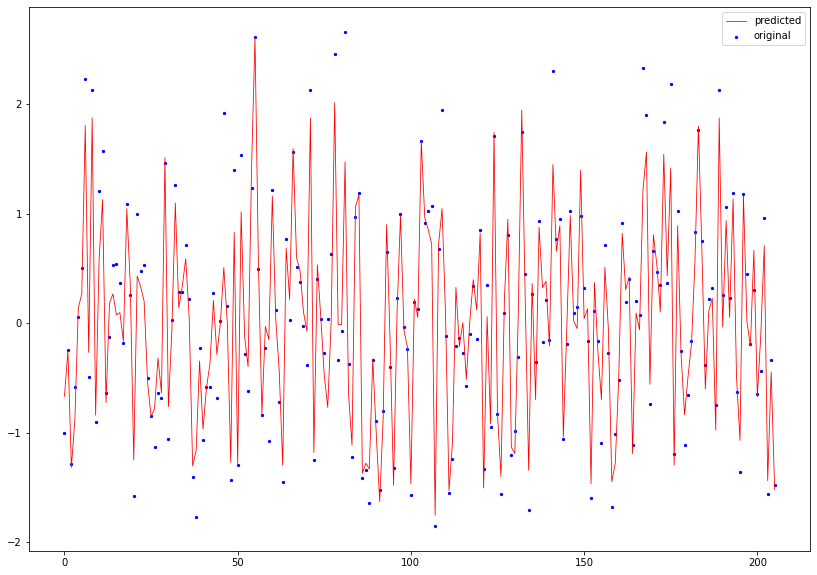

```python
# Gradient Boosting Regression produced the best R2 score, therefore create a
# graphical representation of the results comparing predicted to original.
ypred = gbr.predict(X_validate)

mse = mean_squared_error(y_validate,ypred)
print("MSE: %.2f" % mse)

x_ax = range(len(y_validate))

plt.figure(figsize=(14,10))
plt.scatter(x_ax, y_validate, s=5, color="blue", label="original")
plt.plot(x_ax, ypred, lw=0.8, color="red", label="predicted")
plt.legend()
plt.show()
```

## 2.Techniques employed to squeeze that extra performance out of the model without making it overfit. Use Grid Search or Random Search on any of the two models used above. Make a DataFrame to compare models after hyperparameter tuning and their metrics as above.

### Hyperparameter tuning Ridge Regressor with GridSearchCV

```python
# Determine the optimal hyperparameter value for alpha to be used for the Ridge Linear Regression algorithm
ridge_params = {'alpha':[1e-4, 1e-3, 1e-2, 1e-1, 1, 1.5, 2, 5, 10, 20]}

grid_cv_rlm = GridSearchCV(rlm, ridge_params, cv=5)

grid_cv_rlm.fit(X_train,y_train)
```

```
GridSearchCV(cv=5, estimator=Ridge(),
             param_grid={'alpha': [0.0001, 0.001, 0.01, 0.1, 1, 1.5, 2, 5, 10,
                                   20]})
```

```python
print("R-Squared::{}".format(grid_cv_rlm.best_score_))
print("Best Hyperparameters: \n{}".format(grid_cv_rlm.best_params_))
results.iloc[2,0] = grid_cv_rlm.best_score_
```

```
R-Squared::0.6015127444894383
Best Hyperparameters:
{'alpha': 1.5}
```

### Analysis: The optimal hyperparameter value for alpha is 1.5

```python
# Test dataset evaluation
best_rlm_model = grid_cv_rlm.best_estimator_

y_pred = best_rlm_model.predict(X_test)
arr = np.array(y_test)
residuals = arr.flatten() - y_pred


r2_score = best_rlm_model.score(X_test,y_test)
print("R-squared:{:.3f}".format(r2_score))
print("MSE: %.2f" % mean_squared_error(y_test, y_pred))

results.iloc[3,0] = r2_score
```

```
R-squared:0.626
MSE: 0.40
```

### Hyperparameter tuning Decision Tree Regressor with GridSearchCV

```python
# Determine the optimal hyperparameter values for criterion, min_samples split, max_depth, min_samples_leaf,
# max_leaf nodes to be used for the Decision Tree Regression algorithm
dtm_parms = {"criterion": ["mse", "mae"], "min_samples_split": [5, 10, 20, 40], "max_depth": [2, 6, 8, 10, 12],
              "min_samples_leaf": [5, 10, 20, 40, 100], "max_leaf_nodes": [5, 20, 100]}

grid_cv_dtm = GridSearchCV(dtm, dtm_parms, cv=5)

grid_cv_dtm.fit(X_train,y_train)
```

```
GridSearchCV(cv=5,
             estimator=DecisionTreeRegressor(max_depth=4, max_leaf_nodes=10,
                                             min_samples_split=5,
                                             random_state=8),
             param_grid={'criterion': ['mse', 'mae'],
                         'max_depth': [2, 6, 8, 10, 12],
                         'max_leaf_nodes': [5, 20, 100],
                         'min_samples_leaf': [5, 10, 20, 40, 100],
                         'min_samples_split': [5, 10, 20, 40]})
```

```python
print("R-Squared::{}".format(grid_cv_dtm.best_score_))
print("Best Hyperparameters::\n{}".format(grid_cv_dtm.best_params_))
results.iloc[2,1] = grid_cv_dtm.best_score_
```

```
R-Squared::0.7738358695426987
Best Hyperparameters::
{'criterion': 'mse', 'max_depth': 10, 'max_leaf_nodes': 100, 'min_samples_leaf': 5, 'min_samples_split': 5}
```

### Analysis: The optimal hyperparameter values are 'criterion': 'mse', 'max_depth': 10, 'max_leaf_nodes': 100, 'min_samples_leaf': 5, 'min_samples_split': 5

```
(618,)
```

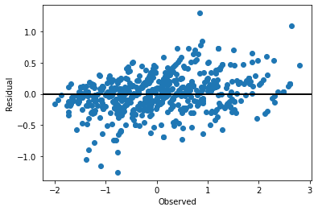

```python
# Evaluating training model
predicted = grid_cv_dtm.best_estimator_.predict(X_train)
print(predicted.shape)
arr = np.array(y_train)
residuals = arr.flatten() - predicted

fig, ax = plt.subplots()
ax.scatter(arr.flatten(), residuals)
ax.axhline(lw=2,color='black')
ax.set_xlabel('Observed')
ax.set_ylabel('Residual')
plt.show()
```

```python
# Test dataset evaluation

best_dtm_model = grid_cv_dtm.best_estimator_

y_pred = best_dtm_model.predict(X_test)
arr = np.array(y_test)
residuals = arr.flatten() - y_pred


r2_score = best_dtm_model.score(X_test,y_test)
print("R-squared:{:.3f}".format(r2_score))
print("MSE: %.2f" % mean_squared_error(y_test, y_pred))

results.iloc[3,1] = r2_score
```

```
R-squared:0.771
MSE: 0.25
```

### Hyperparameter tuning Gradient Boosting Regressor with GridSearchCV

```python
# Determine the optimal hyperparameter values for n_estimators, max_features, and criterion to be used for
# the Gradient Boosting Regression algorithm
gbr_parms = {'n_estimators':[500, 600, 700],
            'max_features':[1, 3, 5, 8], 'criterion':['friedman_mse',  'mae']}

grid_cv_gbr = GridSearchCV(gbr, gbr_parms, cv=5, n_jobs=4)

grid_cv_gbr.fit(X_train,y_train)
```

```
GridSearchCV(cv=5,
             estimator=GradientBoostingRegressor(learning_rate=0.01,
                                                 max_depth=5,
                                                 min_samples_split=3,
                                                 n_estimators=600),
             n_jobs=4,
             param_grid={'criterion': ['friedman_mse', 'mae'],
                         'max_features': [1, 3, 5, 8],
                         'n_estimators': [500, 600, 700]})
```

```python
print("R-Squared: {}".format(grid_cv_gbr.best_score_))
print("Best Hyperparameters::\n{}".format(grid_cv_gbr.best_params_))
results.iloc[2,2] = grid_cv_gbr.best_score_
```

```
R-Squared: 0.9084883817448286
Best Hyperparameters::
{'criterion': 'friedman_mse', 'max_features': 3, 'n_estimators': 700}
```

### Analysis: The optimum hyperparamter values are 'criterion': 'friedman_mse', 'max_features': 3, 'n_estimators': 700

```python
gbr.fit(X_train, y_train)
print("R-Squared on train dataset={}".format(gbr.score(X_train,y_train)))

gbr.fit(X_test,y_test)
print("R-Squaredon test dataset={}".format(gbr.score(X_test, y_test)))
```

```
R-Squared on train dataset=0.9790022770672904
R-Squaredon test dataset=0.9967050715605685
```

```python
# Test dataset evaluation

best_gbr_model = grid_cv_gbr.best_estimator_

y_pred = best_gbr_model.predict(X_test)
arr = np.array(y_test)
residuals = arr.flatten() - y_pred

r2_score = best_gbr_model.score(X_test,y_test)
print("R-squared:{:.3f}".format(r2_score))
print("MSE: %.2f" % mean_squared_error(y_test, y_pred))

results.iloc[3,2] = r2_score
```

```
R-squared:0.906
MSE: 0.10
```

### Compare the results from all 3 algorithms for training, evaluating, tuning, and testing steps

```python
print(results)
```

```
             Ridge Decision Tree Gradient Boosting
train     0.613612      0.698239          0.979002
validate  0.622981      0.714015          0.916763
tune      0.601513      0.773836          0.908488
test      0.626366      0.770781          0.906101
```

### Analysis: From the above table gradient Boosting is the best of the thre algorithm tested with the concrete mizture and compression strength data

### Analysis: the best results were provided by Gradient Boosting Regression Model with an R2 Score of .906 for the test data set.

```
MSE: 0.0035
```

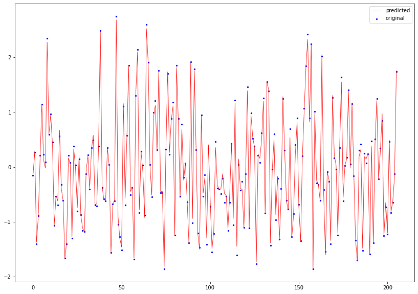

```python
ypred = gbr.predict(X_test)

mse = mean_squared_error(y_test,ypred)
print("MSE: %.4f" % mse)

x_ax = range(len(y_test))
plt.figure(figsize=(14,10))
plt.scatter(x_ax, y_test, s=5, color="blue", label="original")
plt.plot(x_ax, ypred, lw=0.8, color="red", label="predicted")
plt.legend()
plt.show()
```

### Analysis: After review of the above graph the final model may be too good, resulting from overfitting.

## Implementing k Fold Cross Validation

```python
data = df_coded.to_numpy()
X = data[:,0:8]
y = data[:,8]

X_train, X_test, Y_train, Y_test = train_test_split(X, y, test_size=0.50, random_state=1)

number_folds = 10
seed =8

kfold =KFold(n_splits=number_folds, shuffle=True, random_state=seed)

model = GradientBoostingRegressor(n_estimators=700,
    criterion='friedman_mse',
    max_depth=5,
    learning_rate=0.01,
    min_samples_split=3,
    max_features=3)
```

```python
results = cross_val_score(model, X, y, cv=kfold)
print(results)
print("Accuracy: %.3f%% (%.3f%%)" % (results.mean()*100.0, results.std()*100.0))
```

```
[0.94448539 0.92745491 0.89668222 0.90560286 0.96307429 0.93296149
 0.94019565 0.94252638 0.91426412 0.93512296]
Accuracy: 93.024% (1.886%)
```